# DATA 602 - Certain Probability Models of Continuous Random Variables

© Jim Stallard 2019

Up to this point, you have been exposed various forms of *discrete* probability models that provide a probabilistic description of a certain type of event. For instance, the Binomial distribution describes the probabilistic behavior of a count observed after a series of $n$ independent Bernoulli trials have been completed.

In this module, you will be exposed to certain types of *continuous* probability models.

# The Uniform Distribution

**Definition:** A random variable $X$ is said to follow a uniform distribution if and only if the probability density function of $X$ is given by
$$f(x) = \left \{
\begin{array}{ll}
\frac{1}{b - a} & {\rm for\:\:} a \leq x \leq b \\
0 & {\rm otherwise} \\
\end{array}
\right.$$

The **cumulative distribution function** of a Uniformly distributed random variable, $P(X \leq X)$, is also given
$$F(x) = \left \{
\begin{array}{ll}
0 & {\rm for\:\;} x < a \\
\frac{x - a}{b - a} & {\rm for\:\:} a \leq x < b \\
1 & {\rm for \:\:} x \geq b \\
\end{array}
\right.$$

Below is an example of a uniformly distributed random variable $X$ between 2 and 12:

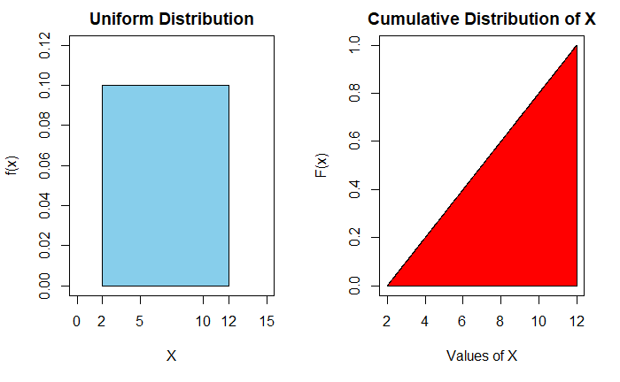

In this instance, the area of rectangle *should be equal to 1*. This can be checked using the formula that finds the area of a rectangle, where the length is equal to $12 - 2 = 10$ and the width is $\frac{1}{12 - 2} = \frac{1}{10} = 0.10$
$$Area = length*width = (12 - 2)*\frac{1}{12 - 2} = 1$$
This can be verified with either
$$\int_{2}^{12}\left(\frac{1}{12 - 2} \right)dx = \int_{2}^{12}\left(\frac{1}{10} \right)dx = \frac{1}{10}*(12 - 2) = 1$$
**Example 1:** Consider the random variable $X$ that is uniformly distributed between 2 and 12. Compute $P(5 \leq X \leq 6)$
**Answer:** Looking at the above distribution, to compute $P(5 \leq X \leq 6)$ is to compute the area

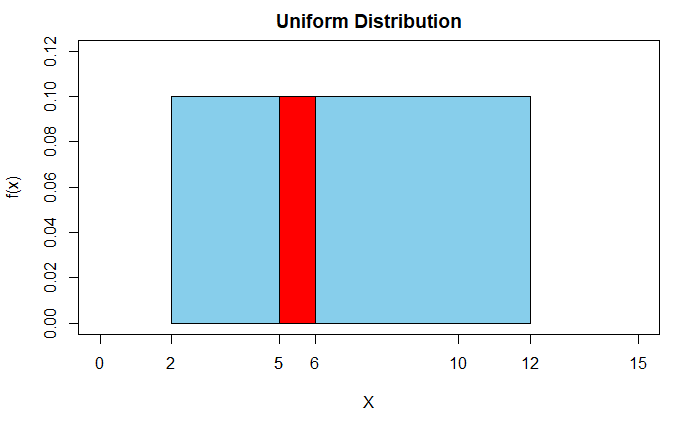

$$P(5 \leq X \leq 6) = \int_{5}^{6}\left(\frac{1}{12 - 2}\right)dx = ?$$
Using our knowledge of probability and continuous random variables, this can be computed by

This can also be computed with R. There are three built in functions that enable you to work with a Uniform distribution between two points:

- `dunif(x, a, b)` will compute the *value of the probability density function $\frac{1}{b - a}$ at the value of `x`
- `punif(x, a, b)` will compute the *cumulative probability* at $x$ or evaluates $F(x) = P(X \leq x)$
- `qunif(p, a, b)` will return the $pth$-percentile for a given value of a Uniformly distributed random variable $X$

Since
$$P(5 \leq X \leq 6) = P(X \leq 6) - P(X \leq 5) = F(6) - F(5)$$

```r
punif(6, 2, 12) - punif(5, 2, 12)  #computes P(X <= 6) - P(X <= 5)
```

**Example 2:** The cycling time for a truck hauling asphalt to a road paving construction site can be modeled by a Uniform distribution between 30 and 50 minutes. Compute the probability that the cycling time for a certain truck  
(a) takes between 35 and 40 minutes.  
**Answer:** Here the probability $P(35 \leq X \leq 40)$ needs to be computed. Visually, the probability density function is provided below with the $P(35 \leq X \leq 40)$ provided:

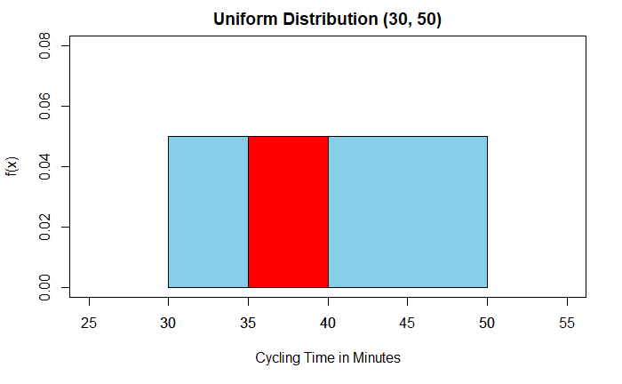

This probability is then computed as
$$\begin{aligned}
P(35 \leq X \leq 40) = & \int_{35}^{40}\left(\frac{1}{50 - 30}\right)dx \\
= & \left(\frac{40 - 35}{50 - 30}\right) \\
= & \frac{5}{20} \\
= & 0.25
\end{aligned}$$
or
$$\begin{aligned}
P(35 \leq X \leq 40) = & P(X \leq 40) - P(X \leq 35) \\
= & F(40) - F(35) \\
= & \left(\frac{40 - 30}{50 - 30} \right) - \left(\frac{35 - 30}{50 - 30} \right) \\
= & \frac{5}{20} \\
= & 0.25
\end{aligned}$$
R can be used to compute $P(35 \leq X \leq 40)$. The command below uses the “cdf” approach:

```r
punif(40, 30, 50) - punif(35, 30, 50)
```

(b) If the cycling time of a certain load of asphalt has taken at least 40 minutes, compute the probability that it will take *at most* 45 minutes.
**Answer:** In this instance, some event has occurred - the cycling time of the truck is at least 40 minutes $X \geq 40$. *Given this*, it is requires to compute that the cycling time of this truck is at most/no more than 45 minutes, $P(X \leq 45 | X \geq 40)$.
$$\begin{aligned}
P(X \leq 45|X \geq 40) = & \frac{P((X \geq 40) \cap (X \leq 45))}{P(X \geq 40)} \\
= & \frac{P(40 \leq X \leq 45)}{P(X \geq 40)} \hspace{0.5in} ((X \geq 40) \cap (X \leq 45) = 40 \leq X \leq 45)\\
= & \frac{\int_{40}^{45}\left(\frac{1}{50 - 30} \right)dx}{\int_{40}^{50}\left(\frac{1}{50 - 30} \right)dx} \\
= & \frac{\frac{5}{20}}{\frac{10}{20}} \\
= & \frac{5}{10} \\
= & 0.50
\end{aligned}$$
This is computed with the R code below

```r
(punif(45, 30, 50) - punif(40, 30, 50))/(1 - punif(40, 30, 50))  #P(40 <= X < = 45)/(1 - P(X < = 40))
```

(c) Compute the 50th percentile. In other words, 50th of the time it will take a trunk hauling asphalt to the paving site at most how many minutes?
**Answer:** To compute the 50th percentile, or $x_{50}$, we can use the cumulative probabilty distribution function of $X$ and set it equal to 0.50:
$$\begin{aligned}
0.50 = & P(X \leq x_{50}) \\
0.50 = & \left(\frac{x_{50} - 30}{50 - 30}\right) \\
0.50 * (50 - 30) = & x_{50} - 30 \\
10 + 30 = & x_{50} \\
40 \:\:\text{minutes} = X_{50}
\end{aligned}$$
This can be computed with the `qunif` command below:

```r
qunif(0.50, 30, 50)  #comptues the 50th percentile for a uniform distribution between 30 and 50
```

```
[1] 40
```

50% of the time it takes *at most* 40 minutes for a truck to pick up a load of asphalt, dump the load, and return to pick up another load. In other words, the *median cycling time* is 40 minutes.

### The Mean/Expectd Value and Standard Deviation of a Uniform Distribution

**Result:** If $X$ is a random variable that is uniformly distributed on the interval $[a,b]$, then
$$\mu_{X} = E(X) = \frac{a + b}{2} \hspace{1in} \sigma_{X} = \sqrt{\frac{(b - a)^{2}}{12}}$$
**Proof of Expected value:** Althought you will not be required to demonstrate or rejurgitate proofs in this course, it might be worthwhile to demonstrate *where* the mean/expected value result came from:
$$\begin{aligned}
E(X) = & \int_{all\:\:x}x*f(x)dx \\
= & \int_{a}^{b}x\left(\frac{1}{b - a} \right)dx \\
= & \left(\frac{1}{b - a} \right) \left[\frac{x^{2}}{2} \right]_{a}^{b} \\
= & \left(\frac{1}{b - a} \right) \left[\frac{b^{2}}{2} - \frac{a^{2}}{2}\right] \\
= & \left(\frac{1}{2(b - a)} \right)\left[b^{2} - a^{2} \right] \\
= & \left(\frac{1}{2(b - a)} \right)(b - a)(b + a) \hspace{0.5in}( b^{2} - a^{2} = (b - a)(b + a))\\
= & \frac{1}{2}(b + a)
\end{aligned}$$

**Time to Play Uniform:** In using the triangulation method to determine the range of an acoustic source, the test equipment must accurately measure the time at which the spherical wave front arrives at a receiving sensor. According to Perruzzi and Hillard (1984), measurement errors $X$ in these times can be modeled as possessing a Uniform distribution from -0.05 to +0.05 $\mu$s (microseconds).

1. Sketch the probability distribution.
2. State the probability density function $f(x)$ and the cumulative distribution function $F(x)$.
3. Compute the probability that a particular arrival-time measurement will be accurrate to within 0.02 $\mu$s.
4. Compute the median value.
5. Compute the mean/expected value $\mu_{X}$ or $E(X)$.
6. Compute the standard deviation $\sigma_{X}$ or $SD(X)$.
7. If the arrival-time measurement is accurate to 0.02 $\mu$s, compute the probability that it will be accurate to within 0.005 $\mu$s.

See the [link](http://people.ucalgary.ca/~jbstall/Answers/AnswerTimetoPlayUniform.nb.html) to affirm your result.

# The Normal Distribution

The Normal distribution, sometimes referred to as the Gaussian distribution, is probably one of the most important probability distributions you will learn about. This distribution provides a basis for many of the statistical principles and procedures you will encounter in Data 602 and following Data courses. Below the Normal distibution is defined.

**Definition:** A random variable $X$ is said to follow a normal distribution if and only if the probability distribution function of $X$ is in the form
$$f(x) = \frac{1}{\sqrt{2 \pi * \sigma^{2}}}e^{- \frac{(x - \mu)^{2}}{2 \sigma^{2}}} \hspace{0.5in} - \infty < x < + \infty, \:\: \sigma^{2} > 0$$
where $\mu$ is the mean/expected value and $\sigma$ is the standard deviation of the Normal distribution.

Below is the probability density function of a random variable modeled by the Normal distribution function with a mean $\mu$ of 100 and a standard deviation of $\sigma = 10$, or
$$f(x) = \frac{1}{\sqrt{2 \pi * 10^{2}}}e^{- \frac{(x - 100)^{2}}{2*10^{2}}} \hspace{0.5in} - \infty < x < + \infty, \:\: \sigma^{2} > 0$$

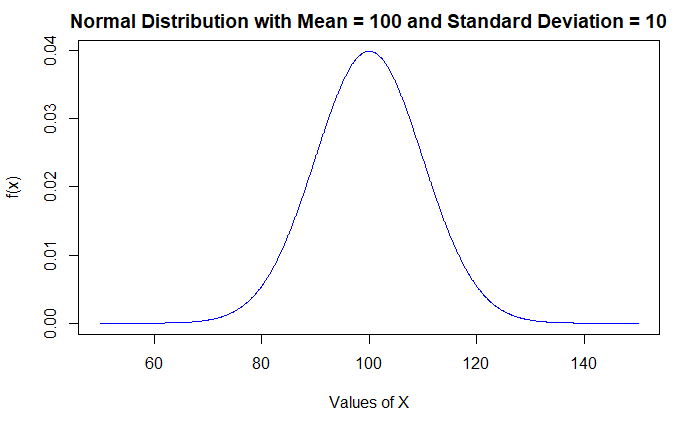

### Computing Probabilities Associated with a Normal Distribution Probability Model

The distribution given below models the behaviour of the amount of time it takes students at a certain university to register for their courses through the online registration system, with a mean of $\mu = 12$ minutes and a standard deviaiton of $\sigma = 3$ minutes:

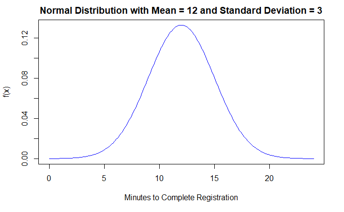

Suppose we wanted to compute the probability that it takes a student between 8 and 15 minutes to register, or $P(8 \leq X \leq 15$). We would be finding the following area:

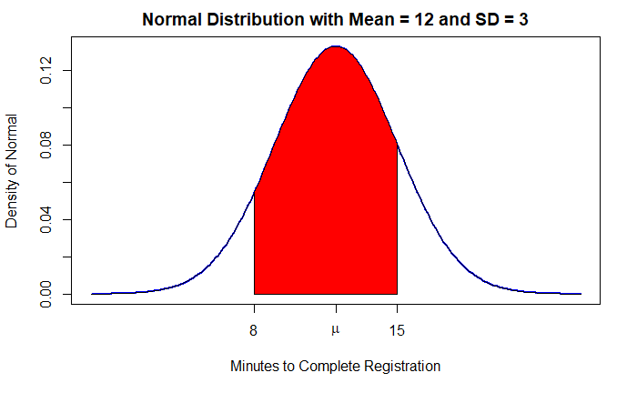

This probability is computed by
$$P(8 \leq X \leq 15) = \int_{8}^{15}\frac{1}{\sqrt{2 \pi * 3^{2}}}e^{- \frac{(x - 12)^{2}}{2 * 3^{2}}}dx = ?$$
To compute such a probability we can create a function in R, the conduct the integration of said function between the two values of 8 and 15. However, R Studio has a build in “normal” function that saves us such an effort. YOu will not be asked to compute this integration in Data 602.

A shortcut to computing this probability invokes the R command `pnorm(x,mean,sd)`, with the **p** in front provding R the instruction to compute the cumulative probability $P(X \leq x)$ for a given mean $\mu$ and a given standard deviation $\sigma$.

To illustrate, suppose we were to compute the probability that it took a student at most 15 minutes to register for their courses, or $P(X \leq 15)$. We side step the integration and compute this cumulative probability within R Studio.

```r
pnorm(15,12,3) #computes P(X <= 15) for mu =12 and sigma = 3
```

and
$$P(X \leq 15) = \int_{-\infty}^{15}\frac{1}{\sqrt{2 \pi 3^{2}}}e^{- \frac{(x - 12)^{2}}{2 3^{2}}}dx = 0.841345$$
To compute the probabilty that it takes a student between 8 minutes and 15 minutes to register in R Studio, the difference between the two cumulative probabilities is computed in R Studio:

```r
pnorm(15,12,3) - pnorm(8,12,3)  #P(X <= 15) - P(X <= 8)
```

and
$$P(8 \leq X \leq 15) = \int_{8}^{15}\frac{1}{\sqrt{2 \pi 3^{2}}}e^{- \frac{(x - 12)^{2}}{2 3^{2}}}dx = 0.750134$$

## Applications of the Normal Distribution Probability Model - Computing Percentiles

**Illustration:** The Society of Actuaries runs a series of professional examinations which much be passed by budding actuaries who wish to advance in their actuarial careers. One of these exams is Exam P - Probability. The exam scores for Exam P are Normally distributed with a mean of $\mu_{X} = 70\%$ and a standard deviation of $\sigma_{X} = 8\%$. In order to pass Exam P, a student must score above the 70th percentile. Compute the mark the student must earn in order to pass Exam P.

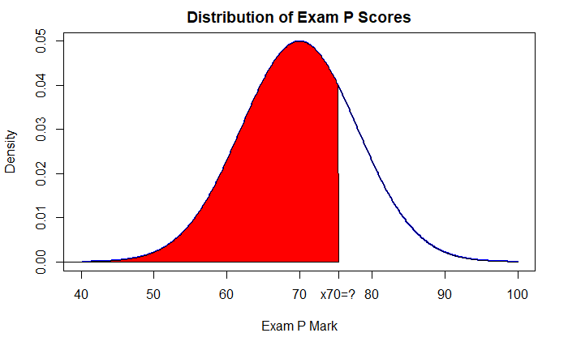

We can find the $x$-value such that $P(X \leq x_{70})$ with the R command `qnorm(percentile, mean, sd)`, where the percentile argument corresponds to the cumulative probability. In our case, we use

```r
qnorm(0.70, 70, 8)   # returns a x-value such that P(X <= x) = 0.70
```

and $x_{0} = 74.1952$. In order to pass Exam P, the student must acheive a mark *above* 74.1952% $\approx$ 74.20%.

**Application** Let’s continue with the Exam P situation. Within R Studio, Compute the probability that a student scores  
(a) more than 80% on Exam P.  
**Answer:** To compute $P(X \geq 80)$, the area below neesd to be computed:

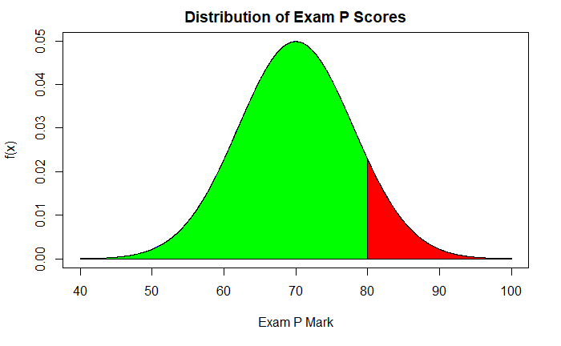

The law of complement is used as $P(X \geq 80) = 1 - P(X < 80)$, where $P(X < 80)$ is outlined above

```r
1-pnorm(80,70,8)  #1 - P(X <= 80)
```

```
[1] 0.1056498
```

and $P(X \geq 80) = 0.1056498 \approx 0.1056$. The chance/probabilty that a student scores more than 80% on Exam P is 0.1056, or 10.56%.

(b) between 50% and 65%.  
**Answer:** Similar to part (a), the region below represents $P(50 \leq X \leq 65)$:

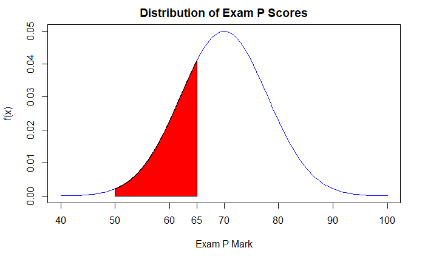

This is computed with

```r
pnorm(65,70,8) - pnorm(50,70,8) #P(X <= 65) - P(X <= 50)
```

```
[1] 0.2597759
```

and $P(50 \leq X \leq 65) = 0.2597759 \approx 0.2598$. The chance/probability that a student scores between 50% and 65% on Exam P is 0.2598, or 25.98%.

(c) 90% of students who write Exam P score at most “how high”?  
**Answer:** In this instance, you are not required to compute a probability. Rather, you have been given a probability. The 90th percentile statement means that $0.90 = P(X \leq x_{90})$ from which the unknown value of $x_{90}$ can be determined with the `qnorm(percentile, mean, sd)` command:

```r
qnorm(0.90,70,8) #computes 90th percentile
```

```
[1] 80.25241
```

90% of those writing Exam P have a mark that is 80.25% or lower. *Or*, the probability that a student scores 80.25% or lower on Exam P is 0.90.

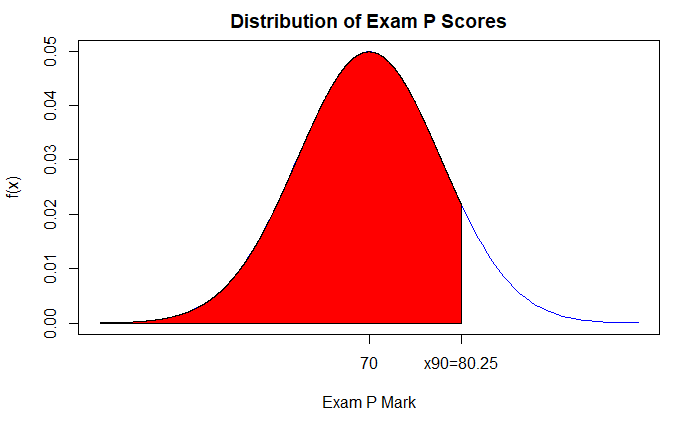

**Time to Play Normal:** The annual rate of return on a certain mutual fund varies from one year to the next in accordance with a Normal probabilit model with a mean/average annual rate of return of 10.1%, or $\mu = 10.1$. While this is certainly an attracive mean annual rate of return, the *risk* of this mutual fund is substantial and is quantified with a standard deviation of $\sigma = 18.0$%. Consider the rate of the return on this particular mutual fund for the current year.

1. Sketch the distribuiton of the annual rate of return of this particular mutual fund.
2. Compute the probability that this year’s rate of return of this particular mutual fund will be more than 30%.
3. Refer to part (b): compute the probability that this year’s rate of return will be between -30% and 0%.
4. Compute both the 10th and 90th percentiles, $x_{10}$ and $x_{90}$, respectively. Also,interpret the meaning of each.

After you have finished playing with this probllem, refert to the [link](http://people.ucalgary.ca/~jbstall/Answers/AnswerTimetoPlayNormal.nb.html) to affirm your result.

# The Gamma Distribution

The two types of continuous distributions that have been covered thus far are both perfectly symmetrical. There is a different class of continuous probability distributions that

1. only assume non-negative values ($x \geq 0$)
2. are right-skewed

One family of such distributions belongs to the Gamma family of distributions. The definition of a Gamma random variable is provided below.

**Definition:** A random variable $X$ is said to follow a Gamma distribution if and only if the probability density function of $X$ is given by
$$f(x) = \frac{1}{\Gamma(\alpha)\beta^{\alpha}}x^{\alpha - 1}e^{-\frac{x}{\beta}} \hspace{0.75in} \alpha, \beta > 0, \hspace{0.1in} x \geq 0$$
The Gamma distribution has two parameters, $\alpha$ and $\beta$; the mean/expected value and the standard deviation of the Gamma random variable are provided respectively,

$$\mu_{X} = E(X) = \alpha*\beta \hspace{0.5in} \sigma_{X} = SD(X) = \sqrt{\alpha * \beta^{2}}$$

To give you a sense of “how” the Gamma distribution behaves for various values of $\alpha$ and $\beta$, below are three different types of Gamma distributions:

- for $\alpha = 2$ and $\beta = 1$
- for $\alpha = 2$ and $\beta = 2$
- for $\alpha = 2$ and $\beta = 3$

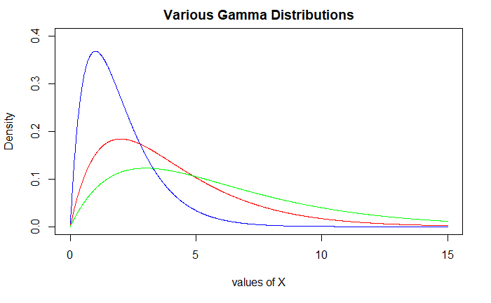

There are two special cases of Gamma distributions,

1. When $\alpha = 1$
2. When $\beta = 2$ and $\alpha = \frac{df}{2}$

## 1. The Exponential Distribution

**Definition:** A random variable $X$ is said to follow an Exponential distribution if and only if $X$ follows a Gamma distribution with $\alpha = 1$. The probability density function is then

$$f(x) = \frac{1}{\Gamma(1)\beta^{1}}x^{1 - 1}e^{-\frac{x}{\beta}} = \frac{1}{\beta}e^{-\frac{x}{\beta}} \hspace{0.5in} {\rm for\:\:} x \geq 0$$
The mean/expected value and the standard deviation of an Exponentially distributed randomv variable is

$$\mu_{X} = E(X) = \alpha * \beta = 1*\beta = \beta \hspace{1in} \sigma_{X} = \sqrt{1*\beta^{2}} = \beta$$

Below are various Exponential distributions with a a mean of (i) $\beta = 1$ (ii) $\beta = 2$ and (iii) $\beta = 5$.

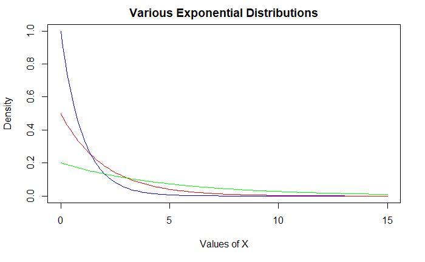

Supose we wanted to compute the probability that a customer will wait at most 5 minutes until they are to be served by the cashier, $P(X \leq 5)$. This computation can be accomplished in one of two ways: 1. $P(X \leq 5)$ using the probability density function of the Exponential distribution where $\beta = 5$ is
$$f(x) = \left(\frac{1}{5} \right)e^{-x/5} \:\: \text{for} \:\:x \geq 0$$
The area of interest in the graph above is

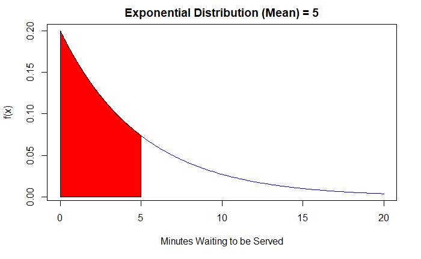

and
$$\begin{aligned}
P(X \geq 50) = & \int_{0}^{5}\left(\frac{1}{5} \right)e^{-x/5}dx = \left[-e^{-x/5} \right]_{0}^{5} = 1 - e^{-1} = 1- 0.367879 = 0.6321206\approx 0.6321
\end{aligned}$$
2. Use of R. There are two built-in R commands specific for the Exponential distribution:

In this instance, to compute $P(0 \leq X \leq 5)$ the can use the `pexp(x, 1/beta)` is employed:

```r
pexp(5,1/5) # P(X <= 5) with mean/beta = 5
```

```
[1] 0.6321206
```

and
$$P(X \leq 5) = \int_{0}^{5}\left(\frac{1}{5}\right)e^{-x/5}dx = 0.6321206$$

**Example 1:** Imagine you are waiting in this particular line.  
(a) Compute the probability that you wait (i) between 1 and 3 minutes until you are served by the cashier (ii) you wait more than 10 minutes.  
**Answer to (i):** To compute $P(1 \leq X \leq 3)$ is to compute the size of the red region below relative to the total area beneath the left-sloping curve, $f(x)$.

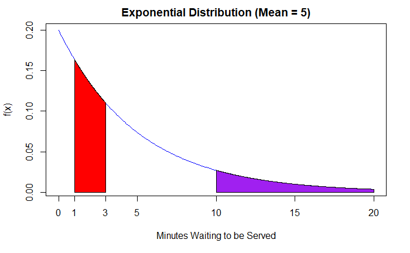

The computation of $P(1 \leq X \leq 3)$ is done with R below

```r
pexp(3, 1/5) - pexp(1, 1/5) #P(X <= 3) =- P(X<= 1)
```

```
[1] 0.2699191
```

from which
$$P(1 \leq X \leq 3) = \int_{1}^{3}\left(\frac{1}{5}\right)e^{-x/5}dx = \left[ -e^{-x/5}] \right]_{1}^{3} = 0.2699191 \approx 0.2699$$
To answer (ii) $P(X > 10)$, use the law of complement as this is equal to $1 - P(X \leq 10)$

```r
1- pexp(10, 1/5)  #1 - P(X < = 10)
```

```
[1] 0.1353353
```

and
$$P(X > 10) = 1 - P(X \leq 10) = 1 - \int_{0}^{10}\left(\frac{1}{5}\right)e^{-x/5}dx = 1 - \left[ -e^{-x/5}] \right]_{0}^{10} = 0.135353 \approx 0.1353$$
(b) Consider the *median* waiting time. Do you think the median waiting time is the saem value as the mean waiting time of $\mu_{X} = 5$ minutes?
**Answer:** To compute $x_{50}$, we could do the following:
$$\begin{aligned}
0.50 = & \int_{0}^{x_{50}}\left(\frac{1}{5}\right)e^{-x/5}dx \:\: (\text{this solves to}) \\
0.50 = & 1 - e^{(-x_{50}/5)}
\end{aligned}$$
Rather, the `qexp(percentile, 1/beta)` function to return the percentile of interest. In this case, percentile=0.50 and

```r
qexp(0.50, 1/5)  #returns the 50th percentile of Exponential with a mean of 5
```

```
[1] 3.465736
```

and $x_{50} = 3.4657 \approx 3.47$ minutes. Fifty-percent of the time, a person waits at most 3.47 minutes to be checked out. This is demonstrated in the distribution below. Observe how the median of 3.47 minutes is different in value than the mean of 5 minutes.

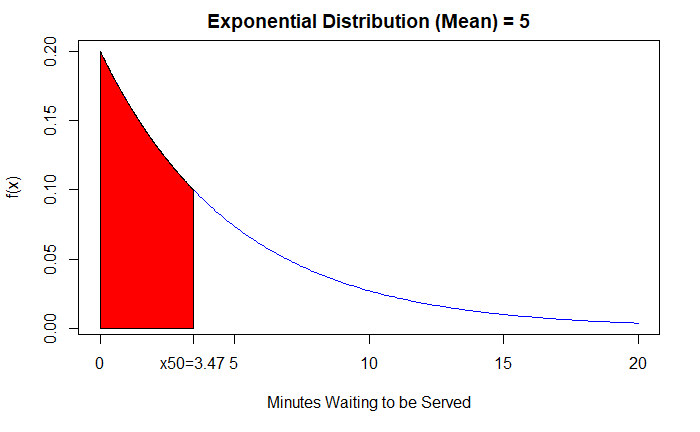

(c) Suppose you have waited to be served by the cashier for at least 5 minutes. Compute the probability that you will have to wait at most 10 minutes in total.
**Answer:** Here we need to compute $P(X \leq 10| X \geq 5)$, which is computed with
$$\begin{align}
P(X \leq 10 | X \geq 5) = & \frac{P(5 \leq X \leq 10)}{P(X \geq 5)} \\
= & \frac{\int_{5}^{10}\frac{1}{5}e^{-x/5}dx}{1- \int_{5}^{\infty}\frac{1}{5}e^{-x/5}dx} \\
= & \frac{{\rm pexp(10,1/5)} - {\rm pexp(5,1/5)}}{1- {\rm pexp(5,1/5)}}
\end{align}$$

Let’s compute this ratio within R Studio:

```r
(pexp(10,1/5) - pexp(5,1/5))/(1-pexp(5,1/5))
```

```
[1] 0.6321206
```

from which
$$P(X \leq 10 | X \geq 5) = 0.6321$$
If you have waited at least 5 minutes, the probability of waiting a total of *at most 10 minutes* is 0.6321. What is of interest here is that this conditional probability is the *same as* $P(X \leq 5)$:

```r
pexp(5, 1/5)
```

```
[1] 0.6321206
```

**Result:** Consider a random variable $Y$ that counts the number of occurrences of a certain event in a well-defined time region with a mean $\mu_{Y} = E(Y) = \lambda$. Another random variable $X$ is defined to measure *either* of + the amount of that passes until the *first* event occurs + the amount of time that passes between successive events, $Y_{i} - Y_{i - 1}$, called the *interarrival time*

$X$ can be modeled by the Exponential distribution, where the mean is $E(X) = \beta = \frac{1}{\lambda}$ and the probability density function of $X$ is
$$f(x) = \frac{1}{\beta}e^{-x/\beta} = \lambda e^{-x\lambda} \hspace{0.5in} {\rm for\:\:} x \geq 0 \:\: {\rm and\:\:} \lambda > 0$$

**Example 2:** $X$ is a random variable that counts the number of visits to a certain website per second. From our understanding of how to model counts, this particular count can be modeled by the Poisson distribution[^1] with a mean of 100 visits per second, or $\mu_{X} = E(X) = \lambda = 100$.

2. Create the distribution of $Y$ in R Studio.
   **Answer:** The commands below create the Exponential distribution for $Y$, the amount of time passing between successive visits with a probability density function
   $$f(x) = \left(\frac{1}{0.01}\right)e^{-y/0.01} = 100e^{-100*y} \:\:\text{for}\:\; y \geq 0$$

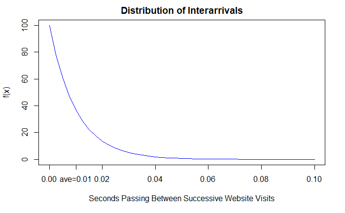

```r
x = seq(0,0.1,0.0025)
plot(x, dexp(x,1/0.01), xlab="Seconds Passing Between Successive Website Visits", ylab="f(x)", main="Distribution of Interarrivals", type="l", col='blue')
meantime=0.01
axis(1, at=meantime, lab=c("ave=0.01"))
```

3. Compute the probability that between 0.015 and 0.03 seconds pass until the next website visit occurs.  
   **Answer:** Since $Y$ is modeled by an Exponential distribution with a $\mu_{Y} = 0.01$, this probability can be computed with straight forwards integration or with R, the latter of which is demonstrated below.

```r
pexp(0.03, 1/0.01) - pexp(0.015, 1/ 0.01)
```

and
$$P(0.015 \leq Y \leq 0.03) = \int_{0.015}^{0.03}100e^{-100*y}dy = 0.173343 \approx 0.1733$$

4. Find the 90th percentile $y_{90}$ and interpret its meaning, in context.  
   **Answer:** To find the value of $y_{90}$, refer to the distribution below:

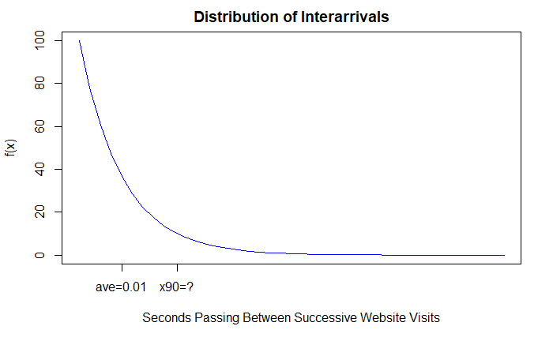

This is computed with

```r
qexp(0.90, 1/0.01)  #computes the 90th percentile of a Exponetial distribution with mean =0.01
```

```
[1] 0.02302585
```

From which $y_{90} = 0.023$ seconds. Ninety-percent of the time, the amount of time passing between successive visits is at most 0.023 seconds.

**Time to Play Exponential:** The magnitute of earthquakes is measured on the Richter scale, invented by Charles F. Richter in 1934. Suppose the magnitude of earthquakes with an epicenter in Southern California is modeled by an Exponential distribution with a mean Richter scale of 5.3.

1. Sketch the distribution shape that describes the random patterns of the Richter scale measurement of an earthquake that has its epicenter in Southern California.
2. Compute the standard deviation of the distribution sketched in part (a).
3. Compute the probability that the earthquake with an epicenter in Southern California will measure between 3 and 4 on the Richter scale.
4. Compute the 25th percentile. Interpret the meaning of your computation.
5. On July 4th 2019, the Ridgecrest[^2] earthquake in Southern California measured 6.4 on the Richter scale. Compute the probability of an earthquake with a southern California epicenter wil have a Richter scale measurement that exceeds the size of Ridgecrest, California earthquake.
6. If the next earthquake in Souther California measures more than 6.4 on the Richter scale, compute the probabilty it will measure more than 7.

Refer to this [link](http://people.ucalgary.ca/~jbstall/Answers/AnswerTimetoPlayExponentialRmd.nb.html) to check your results.

## 2. The Chi-Square ($\chi^{2}$) Distribution

The $\chi^{2}$-distribution has one parameter $df$, which is often referrd to as the *degrees of freedom*, or $df$. Below are three separate $\chi^{2}$-distributions, one with 1 degree of freedom, another with 4 degrees of freedom, and a third with 10 degrees of freedom:

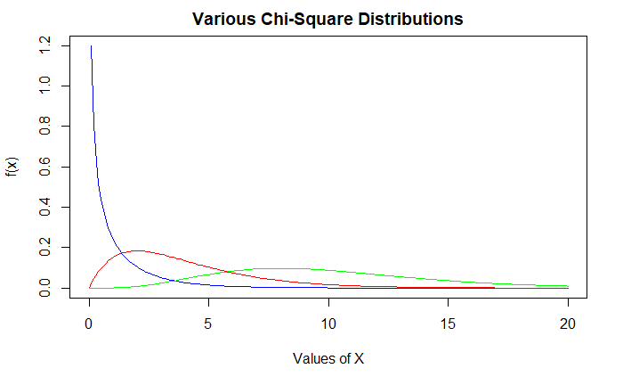

The **pchisq(x,df)** returns $P(\chi^{2}_{df} \leq x)$, the **dchisq(x,df)** returns the *value* of the $\chi^{2}$ density function at $x$, and **qchisq(percentile, df)** returns the $x_{p}$ = pth-percentile of the $\chi^{2}_{df}$.

**Example 1:** A random variable follows a $\chi^{2}$ distribution with $df = 8$.

1. Compute $P(5 \leq \chi^{2}_{8} \leq 15)$ with. R.  
   **Answer:** To compute this probability the R-command `pchisq(x, df)` is used to compute the area below:

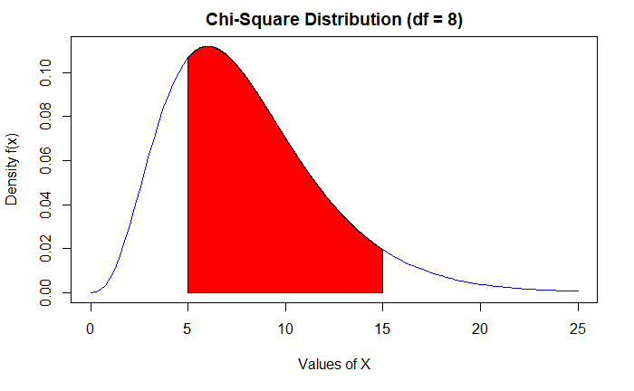

This probability is computed with the `pchisq(x, df)` command, which evaluates $P(\chi^{2}_{df} \leq x)$.

```r
pchisq(15,8) - pchisq(5,8)   # P(ChiSq_{15} <= 15) - P(chisq_{15} <= 8)
```

```
[1] 0.6984307
```

and $P(5 \leq \chi^{2}_{8} \leq 15) = 0.69843$.

2. Compute the 50th percentle $x_{50}$ of a $\chi^{2}_{8}$.  
   **Solution:** Using R to find the value $x_{50}$ such that $P(\chi^{2}_{8} \leq x_{50}) = 0.50$:

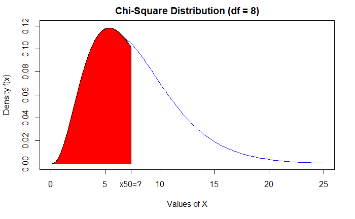

The value of $x_{50}$ is computed with the `qchisq(percentile, df)` command.

```r
qchisq(0.50,8) #computes the 50th percentile of a Chi-square with df = 8
```

```
[1] 7.344121
```

and $x_{50} = 7.34412$. In this instance, 50% of the time a $\chi^{2}$ random variable with $df = 8$ is less than or equal to 7.34412.

**Result:** If a random variable follows a $\chi^{2}$ distribution with $df$, then the mean/expected value and standard deviation are
$$\mu_{X} = E(X) = \alpha * \beta = \frac{df}{2}*2 = df \hspace{0.5in} \sigma_{X} = SD(X) = \sqrt{2*df}$$
**Example 2:** In Example 1, the mean and standard deviation of $\chi^{2}_{8}$, or a $\chi^{2}$ random variable with 8 degrees of freedom, is
$$\mu_{X} = E(X) = df = 8 \hspace{0.2in} \sigma_{X} = SD(X) = \sqrt{2*df} = \sqrt{2*8} = 4$$

**Time to Play $\chi^{2}$:**. A random variable $X$ can be modeled by the $\chi^{2}$ distribution with $df = 15$. Compute

1. *DRAW* this distribution, locating the mean/expected value and the standard deviation. Then, use R Studio to create the same visual display of this distribution.
2. Use R Studio to compute $P(X \geq 25)$.
3. Use R Studio to find the 10th percentile, $x_{10}$

Please refer to this [link](http://people.ucalgary.ca/~jbstall/Answers/AnswerTimetoPlayChiSquare.nb.html) to review your results.

[^1]: Recall the Poisson distribution can be used to model a count that occurs in a (i) well-defined time interval or (ii) a well-define physical region with an expected count/mean count equal to $\lambda$.
[^2]: https://www.latimes.com/local/lanow/la-me-earthquake-california-shake-quake-20190704-story.html